# Team 10 Output Analysis

Team 10

2023-04-19

# Introduction

The goal of our simulation is to analyze whether having 3 ride types (performance, slow train, and spinning-type rides) or 2 ride types (performance and slow train rides) in the theme park is better. In order to do so, we will perform a paired t-test of the 2 different ride configurations while keeping the location of the rides the same.

In this output analysis, our group will aim to analyze the following parameters of our simulation as well as their differences when we compare the two theme park configurations:

1. The average satisfaction level of each customer(`avgScore`)
2. The average queue time per ride (`avg_wait_time`)
3. The average queue time for each type of ride (`avg_queue_time_a`, `avg_queue_time_b`, `avg_queue_time_c`)
4. The average queue time per person (`avg_wait_person`)
5. The average queue time per person for each type of ride (`avg_wait_person_a`, `avg_wait_person_b`, `avg_wait_person_c`)
6. The average profits per person (`average_profits`)
7. The average profits per person from each ride type (`average_profits_a`, `average_profits_b`, `average_profits_c`)

Due to the time constraints, we chose to do do the batch mean approach for data collection. This is because of 2 main reasons:

1. Our simulation is computationally expensive as it takes along time to run.
2. Our burn-in period is quite large, so the replication/deletion method would lead to a lot of wasted data.

## Libraries

```r
library(ggplot2)
library(zoo)
library(tidyverse)
```

# Output Analysis

## Read csv for 3-ride-type data (`data_3_rides.csv`)

```r
sim_data3 <- read.csv("data_3_rides.csv")
sim_data3[is.na(sim_data3)] <- 0 # Replace NA values with 0
head(sim_data3)
```

```
##     time avg_queue_time_a avg_queue_time_b avg_queue_time_c avg_wait_time
## 1 0.5009              0.0                0              0.0     0.0000000
## 2 1.0002              0.0                0              0.0     0.0000000
## 3 1.4999              0.0                0              0.0     0.0000000
## 4 2.0003              0.0                0              0.5     0.1666667
## 5 2.4997              2.5                0              0.5     1.0000000
## 6 2.9995              2.5                0              0.0     0.8333333
##   avg_wait_person avg_wait_person_a avg_wait_person_b avg_wait_person_c
## 1      0.00000000         0.0000000                 0        0.00000000
## 2      0.00000000         0.0000000                 0        0.00000000
## 3      0.00000000         0.0000000                 0        0.00000000
## 4      0.09090909         0.0000000                 0        0.09090909
## 5      0.46153846         0.3846154                 0        0.07692308
## 6      0.33333333         0.3333333                 0        0.00000000
##   total_agts time_in_park time_in_queue average_score average_profits
## 1          4            0             0      100.0000       0.0000000
## 2          6            0             0      100.0000       0.0000000
## 3          9            0             0      100.0000       0.0000000
## 4         11            0             0      100.0000       0.0000000
## 5         13            0             0      100.0000       0.0000000
## 6         15            0             0      102.6262       0.1333333
##   average_profits_a average_profits_b average_profits_c
## 1         0.0000000                 0                 0
## 2         0.0000000                 0                 0
## 3         0.0000000                 0                 0
## 4         0.0000000                 0                 0
## 5         0.0000000                 0                 0
## 6         0.1333333                 0                 0
```

## Determine burn-in period

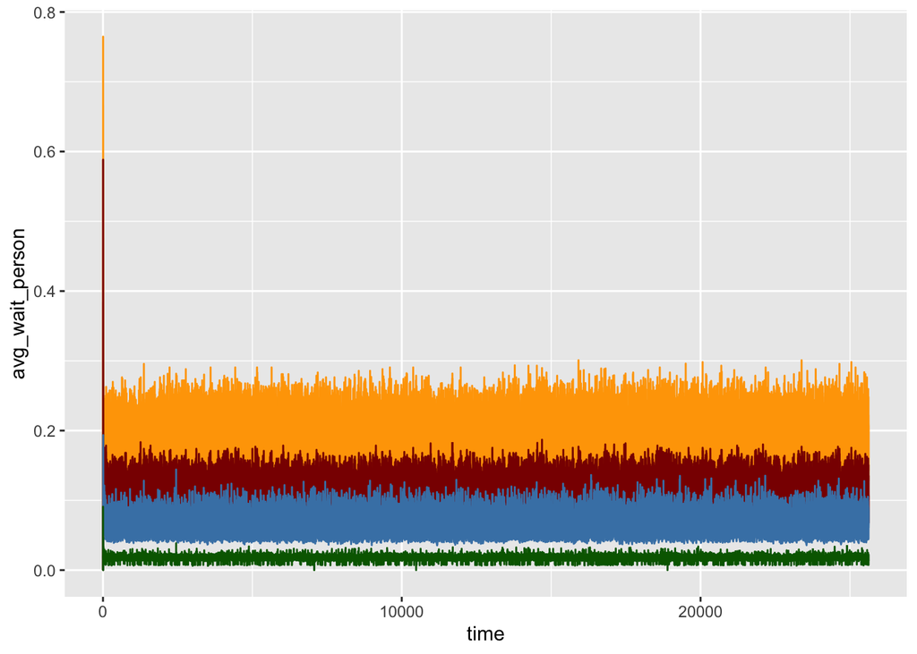

```r
ggplot(sim_data3, aes(time)) +
  geom_line(aes(y = avg_wait_person),color = "orange") +
  geom_line(aes(y = avg_wait_person_a),color = "darkred") +
  geom_line(aes(y = avg_wait_person_b),color = "steelblue") +
  geom_line(aes(y = avg_wait_person_c),color = "darkgreen")
```

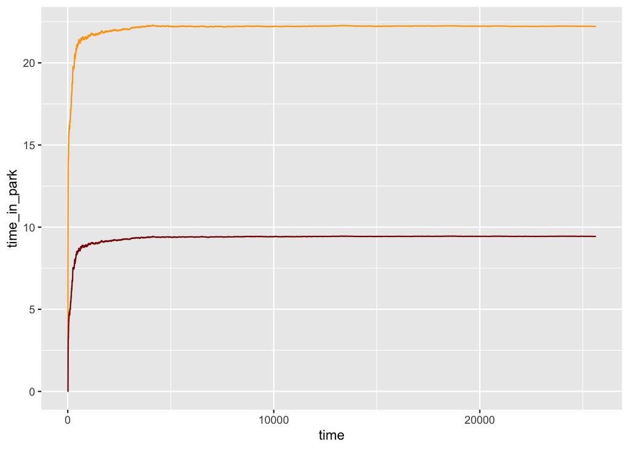

```r
ggplot(sim_data3, aes(time)) +
  geom_line(aes(y = time_in_park),color = "orange") +
  geom_line(aes(y = time_in_queue),color = "darkred")
```

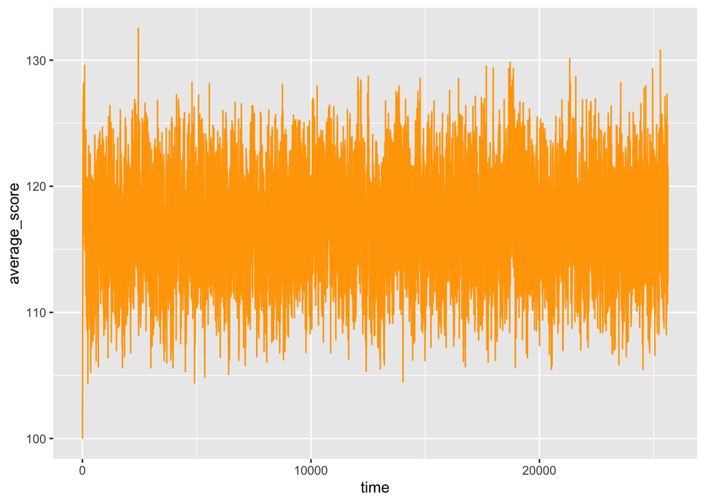

```r
ggplot(sim_data3, aes(time)) +
  geom_line(aes(y = average_score),color = "orange")
```

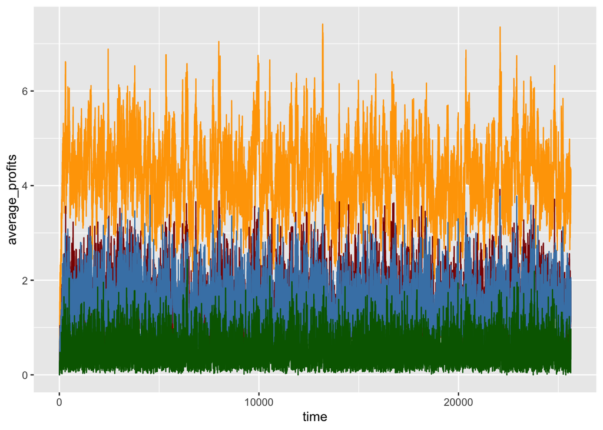

```r
ggplot(sim_data3, aes(time)) +
  geom_line(aes(y = average_profits),color = "orange") +
  geom_line(aes(y = average_profits_a),color = "darkred") +
  geom_line(aes(y = average_profits_b),color = "steelblue") +
  geom_line(aes(y = average_profits_c),color = "darkgreen")
```

From the data, it seems that the burn-in period goes up till time = 3600. Hence, we will filter out values whose time < 3600. We use 3800 as our filter condition to be conservative.

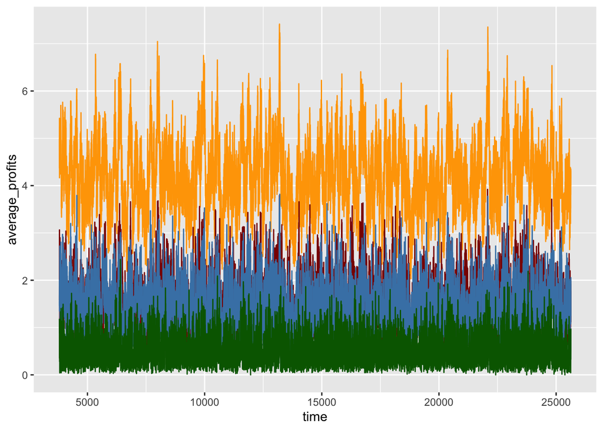

```r
sim_data3_adjusted <- filter(sim_data3, sim_data3$time > 3800)

ggplot(sim_data3_adjusted, aes(time)) +
  geom_line(aes(y = average_profits),color = "orange") +
  geom_line(aes(y = average_profits_a),color = "darkred") +
  geom_line(aes(y = average_profits_b),color = "steelblue") +
  geom_line(aes(y = average_profits_c),color = "darkgreen")
```

We perform the same steps for the two-ride-type simulation data.

## Read csv for two-ride-type data (`2_rides_data_v3.csv`)

```r
sim_data2 <- read.csv("2_rides_data_v3.csv")
sim_data2[is.na(sim_data2)] <- 0 # Replace NA values with 0
sim_data2 <- sim_data2[1:nrow(sim_data3), ] # Because sim_data2 has more rows than sim_data3, we remove sim_data2's excess rows
head(sim_data2)
```

```
##     time avg_queue_time_a avg_queue_time_b avg_wait_time avg_wait_person
## 1 0.5542         0.000000                0     0.0000000       0.0000000
## 2 1.0843         0.000000                0     0.0000000       0.0000000
## 3 1.6680         0.000000                0     0.0000000       0.0000000
## 4 2.2392         1.666667                0     0.8333333       1.2500000
## 5 2.8214         1.666667                0     0.8333333       0.7142857
## 6 3.3927         1.666667                0     0.8333333       0.5000000
##   avg_wait_person_a avg_wait_person_b total_agts time_in_park time_in_queue
## 1         0.0000000                 0          0            0             0
## 2         0.0000000                 0          0            0             0
## 3         0.0000000                 0          3            0             0
## 4         1.2500000                 0          4            0             0
## 5         0.7142857                 0          7            0             0
## 6         0.5000000                 0         10            0             0
##   average_score average_profits average_profits_a average_profits_b
## 1             0               0                 0                 0
## 2             0               0                 0                 0
## 3           100               0                 0                 0
## 4           100               0                 0                 0
## 5           100               0                 0                 0
## 6           100               0                 0                 0
```

## Determine burn-in period

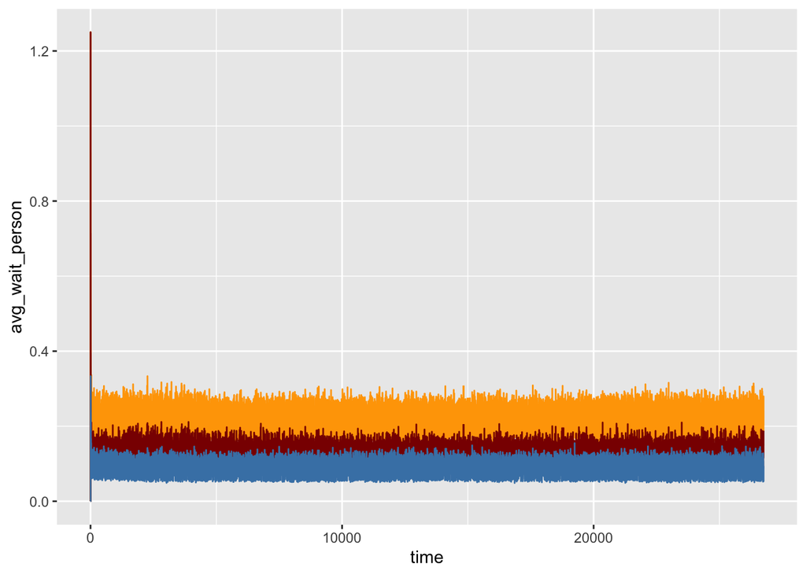

```r
ggplot(sim_data2, aes(time)) +
  geom_line(aes(y = avg_wait_person),color = "orange") +
  geom_line(aes(y = avg_wait_person_a),color = "darkred") +
  geom_line(aes(y = avg_wait_person_b),color = "steelblue")
```

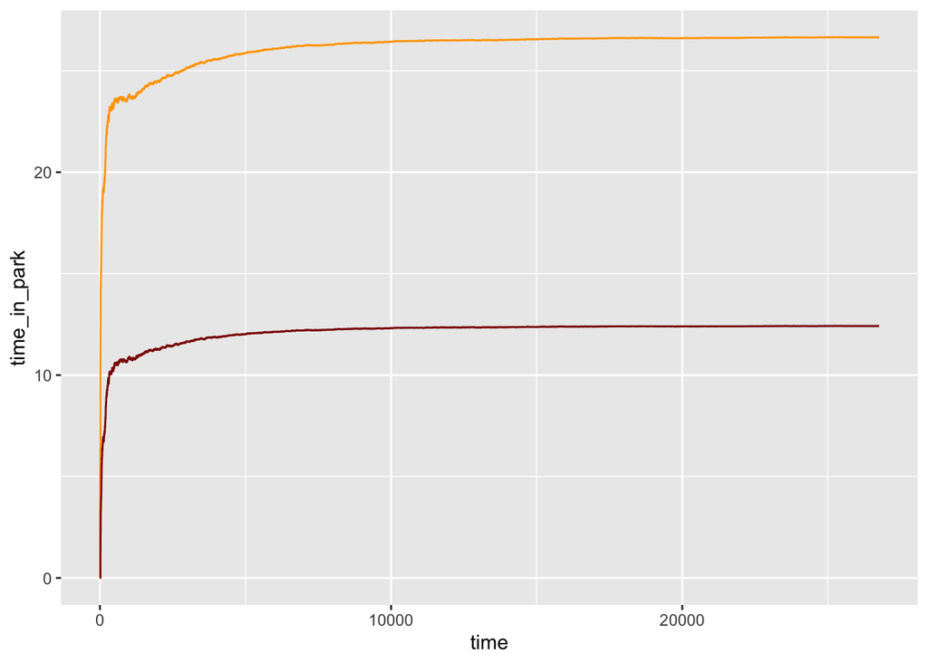

```r
ggplot(sim_data2, aes(time)) +
  geom_line(aes(y = time_in_park),color = "orange") +
  geom_line(aes(y = time_in_queue),color = "darkred")
```

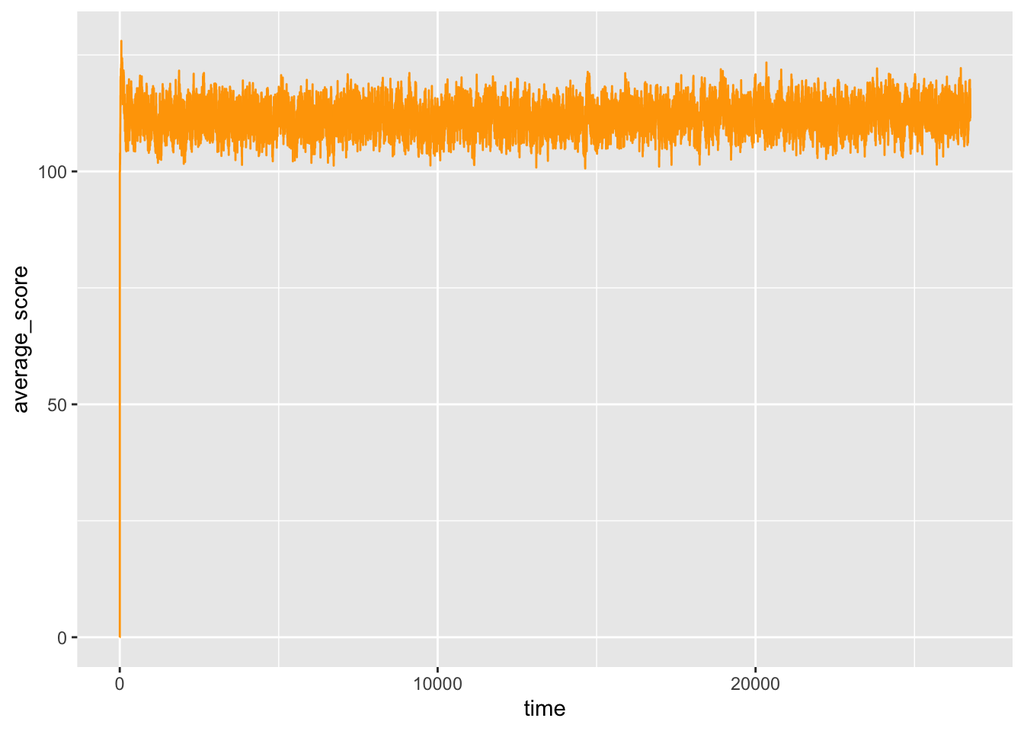

```r
ggplot(sim_data2, aes(time)) +
  geom_line(aes(y = average_score),color = "orange")
```

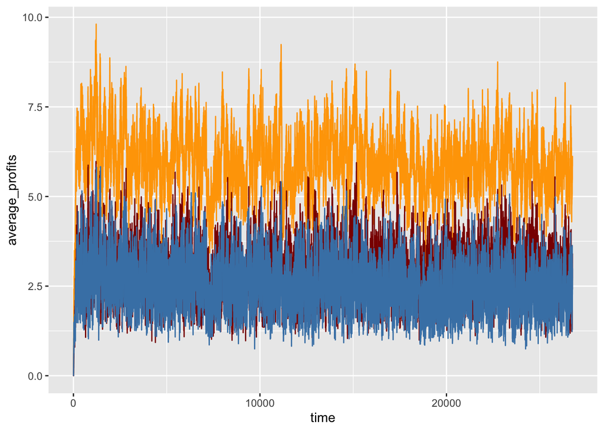

```r
ggplot(sim_data2, aes(time)) +
  geom_line(aes(y = average_profits),color = "orange") +
  geom_line(aes(y = average_profits_a),color = "darkred") +
  geom_line(aes(y = average_profits_b),color = "steelblue")
```

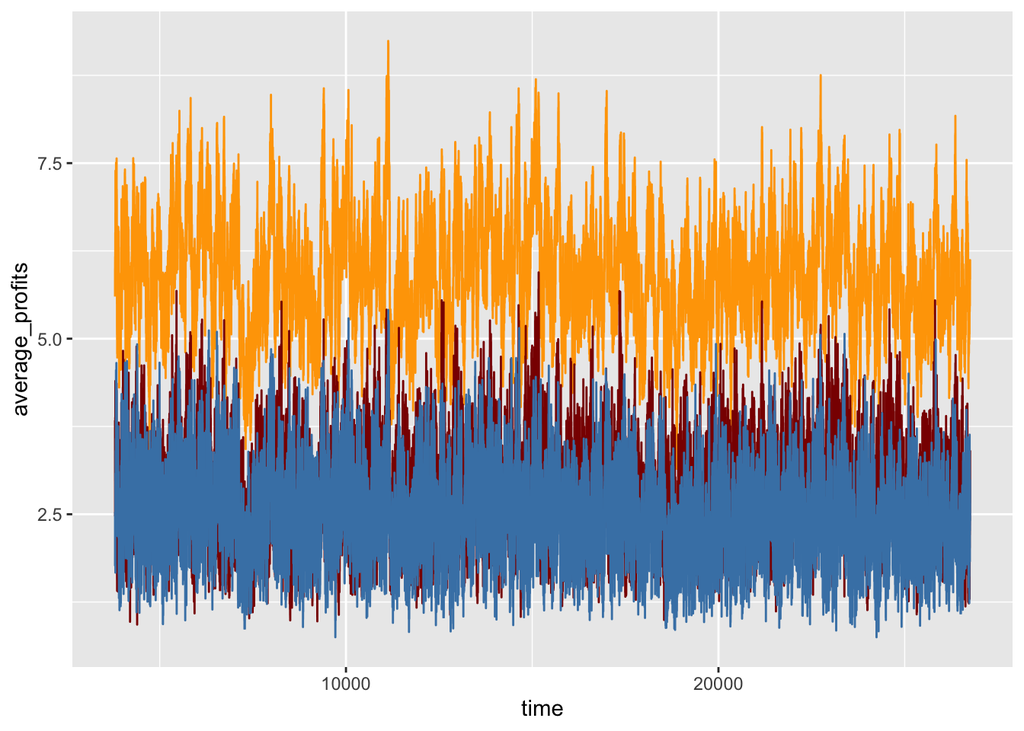

```r
sim_data2_adjusted <- filter(sim_data2, sim_data2$time > 3800)

ggplot(sim_data2_adjusted, aes(time)) +
  geom_line(aes(y = average_profits),color = "orange") +
  geom_line(aes(y = average_profits_a),color = "darkred") +
  geom_line(aes(y = average_profits_b),color = "steelblue")
```

Because `sim_data3_adjusted` has 43663 rows while `sim_data2_adjusted` has 44307 rows, we remove the excess rows from `sim_data2_adjusted`.

```r
sim_data2_adjusted <- sim_data2_adjusted[1:nrow(sim_data3_adjusted), ]
```

## Applying The Batch-Means Method

Divide the data set with the removed initialisation bias into `sqrt(nrow(data_set))` batches.

```r
divide_into_batches <- function(data_set){

  num_obs <- nrow(data_set) # number of observations
  # print(num_obs) # for debugging
  batch_size <- floor(sqrt(num_obs)) # batch size
  # print(batch_size) # for debugging
  num_batches <- floor(num_obs / batch_size) # number of batches
  # print(num_batches) # for debugging

  # Create a new df to store the batched data
  data_set_colnames <- colnames(data_set)
  batched_df <- data.frame(matrix(ncol = length(data_set_colnames), nrow = num_batches))
  colnames(batched_df) <- data_set_colnames

  # for each variable we're observing,
  for (column in 1:ncol(data_set)) {
    # for each batch, calculate the batch/sample mean
    for (batch in 1:num_batches) {
      batch_start_row <- (batch - 1) * batch_size + 1
      batch_end_row <- batch_start_row + batch_size - 1
      batch_mean <- mean(data_set[batch_start_row:batch_end_row, column])
      # for debugging
      # if (is.na(batch_mean)) {
      #   print(c(batch_start_row, batch_end_row, batch, column))
      #   print(data_set[batch_start_row:batch_end_row, column])
      # }
      batched_df[batch, column] <- batch_mean # add the batch_mean to batched_df
    }
  }

  batched_df
}
```

Obtained the batch data for the three-ride-type simulation and the two-ride-type simulation.

```r
three_ride_batched <- divide_into_batches(sim_data3_adjusted)
two_ride_batched <- divide_into_batches(sim_data2_adjusted)
```

Obtain the difference, $Z_j = X_{1j} - X_{2j}$ between each batch between the two simulations for each variable being observed.

$$\text{Identify a confidence interval of } \zeta = \mu_1 - \mu_2 \\
X_{ij} = \text{output } j \text{ from system } i \\
\text{Let }Z_j = X_{1j} - X_{2j}, \text{ so } \mathbb{E}(Z_j) = \zeta$$

```r
three_ride_batched <- subset(three_ride_batched, select = c(colnames(two_ride_batched)))
difference_df <- three_ride_batched - two_ride_batched
```

## Conduct a paired-t confidence interval for the difference between the performance of both theme park configurations for each variable observed.

$$\text{Compute sample mean, } \bar{Z}_n = \frac{1}{n} \sum_{i =
1}^{n}{Z_i} \\
\text{and sample variance, } \hat{\sigma}_n^2 = \frac{1}{n - 1} \sum_{i
= 1}^{n}{(Z_i - \bar{Z}_n)^2} \\
(1 - \alpha) * 100\% \text{ confidence interval for } \mu_1 - \mu_2
\text{ is } (\bar{Z}_n - t_{n-1, \alpha/2} \frac{\hat{\sigma_n}}{\sqrt
n}, \bar{Z}_n + t_{n-1, \alpha/2} \frac{\hat{\sigma_n}}{\sqrt n})$$

```r
calculate_confidence_intervals <- function(difference, alpha){

  # Create a new df to store the batched data
  data_set_colnames <- colnames(difference)
  stats_df <- data.frame(matrix(ncol = length(data_set_colnames), nrow = 4))
  colnames(stats_df) <- data_set_colnames
  rownames(stats_df) <- c("sample_mean", "sample_variance", "lower_bound", "upper_bound")

  for (column in 1:ncol(difference)){

    # Calculate the degrees of freedom, sample mean, sample variance, and lower and upper bounds
    col_values <- difference[, column]
    # print(col_values)
    deg_freedom <- length(col_values) - 1
    sample_mean <- mean(col_values) # sample mean
    sample_variance <- sum((col_values - sample_mean) ^ 2) / (length(col_values) - 1) # sample variance
    upper_bound <- sample_mean + abs(qt(alpha / 2, deg_freedom) * (sqrt(sample_variance) / sqrt(length(col_values))))
    lower_bound <- sample_mean - abs(qt(alpha / 2, deg_freedom) * (sqrt(sample_variance) / sqrt(length(col_values))))

    # print(sample_mean)
    # print(sample_variance)
    # print(lower_bound)
    # print(upper_bound)

    # Store the values in stats_df
    stats_df["sample_mean", column] <- sample_mean
    stats_df["sample_variance", column] <- sample_variance
    stats_df["lower_bound", column] <- lower_bound
    stats_df["upper_bound", column] <- upper_bound
  }

  stats_df

}
```

```r
CI_stats <- calculate_confidence_intervals(difference_df, 0.05)
CI_stats <- subset(CI_stats, select = -c(time, total_agts))
CI_stats
```

```
##                 avg_queue_time_a avg_queue_time_b avg_wait_time avg_wait_person
## sample_mean            0.2160970       -0.1500161   -1.56727319   -2.721595e-02
## sample_variance        0.1255717        0.0747341    0.04724716    1.093763e-05
## lower_bound            0.1677738       -0.1872955   -1.59691448   -2.766694e-02
## upper_bound            0.2644201       -0.1127367   -1.53763190   -2.676495e-02
##                 avg_wait_person_a avg_wait_person_b time_in_park time_in_queue
## sample_mean         -2.250850e-02     -2.055492e-02  -4.22806189   -2.89512718
## sample_variance      1.154534e-05      6.269584e-06   0.06108698    0.01263426
## lower_bound         -2.297185e-02     -2.089637e-02  -4.26176606   -2.91045513
## upper_bound         -2.204515e-02     -2.021347e-02  -4.19435773   -2.87979922
##                 average_score average_profits average_profits_a
## sample_mean          4.728024      -1.7535086        -1.2322787
## sample_variance      3.755518       0.5349222         0.1788641
## lower_bound          4.463756      -1.8532452        -1.2899515
## upper_bound          4.992291      -1.6537720        -1.1746060
##                 average_profits_b
## sample_mean            -0.9605887
## sample_variance         0.1301323
## lower_bound            -1.0097816
## upper_bound            -0.9113959
```

## Display the confidence intervals

Bearing in mind that $Z_j = X_{1j} - X_{2j}$ where $X_1$ refers to the observations for the three-ride-type system while $X_2$ refers to the observations for the two-ride system,

```r
col_names <- colnames(CI_stats)

for (var_name in col_names){
  upper_bound <- signif(CI_stats[3, var_name], 4)
  lower_bound <- signif(CI_stats[4, var_name], 4)
  # for the situations where the upper_bound is more negative than the lower bound
  if (upper_bound < lower_bound) {
    cat(paste0("The confidence interval of Z when it comes to ", var_name, " at 95% confidence is (", upper_bound, ",", lower_bound, ")\n"))
  }
  else {
    cat(paste0("The confidence interval of Z when it comes to ", var_name, " at 95% confidence is (", lower_bound, ",", upper_bound, ")\n"))
  }
}
```

```
## The confidence interval of Z when it comes to avg_queue_time_a at 95% confidence is (0.1678,0.2644)
## The confidence interval of Z when it comes to avg_queue_time_b at 95% confidence is (-0.1873,-0.1127)
## The confidence interval of Z when it comes to avg_wait_time at 95% confidence is (-1.597,-1.538)
## The confidence interval of Z when it comes to avg_wait_person at 95% confidence is (-0.02767,-0.02676)
## The confidence interval of Z when it comes to avg_wait_person_a at 95% confidence is (-0.02297,-0.02205)
## The confidence interval of Z when it comes to avg_wait_person_b at 95% confidence is (-0.0209,-0.02021)
## The confidence interval of Z when it comes to time_in_park at 95% confidence is (-4.262,-4.194)
## The confidence interval of Z when it comes to time_in_queue at 95% confidence is (-2.91,-2.88)
## The confidence interval of Z when it comes to average_score at 95% confidence is (4.464,4.992)
## The confidence interval of Z when it comes to average_profits at 95% confidence is (-1.853,-1.654)
## The confidence interval of Z when it comes to average_profits_a at 95% confidence is (-1.29,-1.175)
## The confidence interval of Z when it comes to average_profits_b at 95% confidence is (-1.01,-0.9114)
```

## Analysing the confidence intervals

| Categories | Three Ride Types | Two Ride Types |
| --- | --- | --- |
| Average queue time at each performance-type (`avg_queue_time_a`) | x | ✓ |
| Average queue time at each slow-train-type (`avg_queue_time_b`) | ✓ | x |
| Average waiting time per attraction (`avg_wait_time`) | ✓ | x |
| Average waiting time per person (`avg_wait_person`) | ✓ | x |
| Average waiting time per person for performance-type (`avg_wait_person_a`) | ✓ | x |
| Average waiting time per person for slow-train-type (`avg_wait_person_b`) | ✓ | x |
| Average time in park per person (`time_in_park`) | ✓ | x |
| Average time in queue per person (`time_in_queue`) | ✓ | x |
| Average satisfaction per person (`average_score`) | ✓ | x |
| Average profits per person (`average_profits`) | x | ✓ |
| Average profits per person for performance-type (`average_profits_a`) | x | ✓ |
| Average profits per person for slow-train-type (`average_profits_b`) | x | ✓ |
| **Total** | **8** | **4** |

Based on the given results, we can see that the confidence intervals for all the variables are not centered around 0, which suggests that there are significant differences between the three-ride-type system and the two-ride system for all the variables.

The confidence interval of $Z$ for `avg_queue_time_a` is (0.1678, 0.2644), which indicates that on average, customers taking performance-type rides in the three-ride-type system experience a 0.1678 to 0.2644 time units longer queue time compared to customers taking performance-type rides in the two-ride system. Similarly, the confidence interval of $Z$ for `avg_queue_time_b` is (-0.1873, -0.1127), which indicates that customers taking slow-train-type rides in the three-ride-type system experience a 0.1127 to 0.1873 time units shorter queue time compared to customers taking slow-train-type rides in a two-ride system.

The confidence interval of $Z$ for `avg_wait_time` is (-1.597, -1.538), which indicates that the waiting time per ride in the three-ride-type system is on average 1.538 to 1.597 time units less than the waiting time in the two-ride system. Similarly, the confidence interval of $Z$ for `avg_wait_person` is (-0.02767, -0.02676), which indicates that each person in the three-ride-type system waits on average 0.02676 to 0.02767 time units less than each person in the two-ride system.

The confidence intervals of $Z$ for `avg_wait_person_a`, `avg_wait_person_b`, `time_in_park`, and `time_in_queue` also suggest that there are significant differences between the two systems for these variables, with customers in the three-ride-type system experiencing less wait time and spending less time in the park and in queues than customers in the two-ride system.

The confidence interval of $Z$ for `average_score` is (4.464, 4.992), which indicates that the average customer satisfaction score in the three-ride-type system is between 4.464 and 4.992 points higher than in the two-ride system. Finally, the confidence intervals of $Z$ for `average_profits`, `average_profits_a`, and `average_profits_b` suggest that the three-ride-type system is less profitable than the two-ride system for all customer.